# Bulk Stock Calls

Will Crouch

8/14/2020

Call packages:

- httr and jsonlite will call the API and process data
- Tidyverse will help clean and process data
- Zoo has great packages applying a function sequentially for time series data
- Fabletools has a great box_cox application function
- Random Forest and xgboost are the model packages

Define the list of stocks to pull, in this case just focusing on the S&P500 ETF by Vangaurd

```r
StockList = c(
              #"BAC" # Bank of America
              #,"AXP" # American Express
              #,"COF" # Capital One
              #,"C"   # Citigroup
              #,"CMA" # Comerica
              #,"JPM" # JPMorgan Chase
              #,"USB" # US Banks
              #,"WFC" # Wells Fargo
              "VOO" # Vanguard ETF S&P 500
              )

StockData = list(rep(data.frame(NA),length(StockList)))
```

With more than 1 stock, the loop will process each independently. The structure stores each df that is returned as a df nested in a list. This allows for easier storage and recalls then creating and naming multiple dfs.

```r
for (i in 1:length(StockList)) {

  StartDate = "1996-01-01"

  Ticker = StockList[i]

  HistCall = paste("https://api.tiingo.com/tiingo/daily/", # Historic Data
                  Ticker,
                  "/prices?startDate=",
                  StartDate,
                  "&format=json&resampleFreq=daily&",
                  APIToken,
                  sep = "")

  HistResponse = httr::GET(HistCall)

  StockData[[i]] = as.data.frame(fromJSON(content(HistResponse, type = "text")))

}
```

```
## No encoding supplied: defaulting to UTF-8.
```

Defining functions for each premade function allows for easier handling and applying when processing the data as well storing complicated formulas that will be applied with rollapply like the Pythagorean means.

```r
# First Difference
FD <- function(x){c(NA,diff(x, lag = 1, differences = 1, fill = NA))}

# Moving N Day Pythagorean Averages
mA <- function(x, n){rollapplyr(lag(x,1), width = n, FUN = mean, fill = NA)}
mHM = function(x, n) { n /rollapplyr(lag(x,1)^-1, width = n, FUN = sum, fill = NA) }
mGM = function(x, n) { rollapplyr(lag(x,1), width = n, FUN = prod, fill = NA)^(1/n)}

# Moving N Day Variance
mVar <- function(x, n){rollapplyr(lag(x,1), width = n, FUN = var, fill = NA)}

# Moving Stochastic Oscillator
mSO <- function(x){(x - rollapplyr(lag(x,1), width = 14, FUN = min, fill = NA)) /
                  (rollapplyr(lag(x,1), width = 14, FUN = max, fill = NA) -
                     rollapplyr(lag(x,1), width = 14, FUN = min, fill = NA)) * 100}

# Spread High and Low over prior N days
mHLSpread = function(x1, x2, n){rollapplyr(lag(x1,1), width = n, FUN = max, fill = NA) -
    rollapplyr(lag(x2,1), width = n, FUN = min, fill = NA)}

# Spread between Close prior N days
mHLC = function(x, n){rollapplyr(lag(x,1), width = n, FUN = max, fill = NA) -
    rollapplyr(lag(x,1), width = n, FUN = min, fill = NA)}
```

Clean data, define Y value, apply functions, transform, and scale. Defined in a loop so that if there are multiple stocks all activities can be performed for each.

```r
for (i in 1:length(StockList)) {

  # Call a single stock's data from Stock Data list
  df = StockData[[i]]

  # Get Y Variable for that will be predicted
  if (i == 1) {
    YVar = df$adjClose
    DateList = as.Date(df$date)
  }

  # Cleaning out data that is eh, or can fuck up with negatives or such
  df$date = NULL
  df$divCash = NULL
  df$splitFactor = NULL

  # Add statistical metrics
  df = df %>%
    mutate("FirstDiff" = FD(adjClose)
           ,"DayMA5" =  mA(FirstDiff,5)
           ,"DayMA10" =  mA(FirstDiff,10)
           ,"DayMA20" =  mA(FirstDiff,20)
           ,"DayMA30" =  mA(FirstDiff,30)
           ,"DayMGM30" = mGM(FirstDiff,30)
           ,"DayMHM30" = mHM(FirstDiff,30)
           ,"DayMA50" =  mA(FirstDiff,50)
           ,"DayMGM50" = mGM(FirstDiff,50)
           ,"DayMHM50" = mHM(FirstDiff,50)
           ,"DayMA100" =  mA(FirstDiff,100)
           ,"DayMGM100" = mGM(FirstDiff,100)
           ,"DayMHM100" = mHM(FirstDiff,100)
           ,"DayMA200" =  mA(FirstDiff,200)
           ,"DayMGM200" = mGM(FirstDiff,200)
           ,"DayMHM200" = mHM(FirstDiff,200)
           ,"DayMVar5" =  mVar(FirstDiff,5)
           ,"DayMVar10" =  mVar(FirstDiff,10)
           ,"DayMVar20" =  mVar(FirstDiff,20)
           ,"DayMVar30" =  mVar(FirstDiff,30)
           ,"DayLag1" = lag(FirstDiff, 1)
           ,"DayLag2" = lag(FirstDiff, 2)
           ,"DayLag3" = lag(FirstDiff, 3)
           ,"StoOsc" = mSO(adjClose)
           ,"ASpread30100" = DayMA30 - DayMA100
           ,"GSpread30100" = DayMGM30 - DayMGM100
           ,"HSpread30100" = DayMHM30 - DayMHM100
           ,"ASpread50200" = DayMA50 - DayMA200
           ,"GSpread50200" = DayMGM50 - DayMGM200
           ,"HSpread50200" = DayMHM50 - DayMHM200
           ,"HighLowSpread1" = mHLSpread(adjHigh, adjLow, 1)
           ,"HighLowSpread5" = mHLSpread(adjHigh, adjLow, 5)
           ,"HighLowSpread10" = mHLSpread(adjHigh, adjLow, 10)
           ,"CloseHLSpread10" = mHLC(adjClose, 10)
           ,"CloseHLSpread20" = mHLC(adjClose, 20)
           ,"CloseHLSpread30" = mHLC(adjClose, 30)
           ,"CloseHLSpread50" = mHLC(adjClose, 50)
           ,"CloseHLSpread100" = mHLC(adjClose, 100)
           ,"CloseHLSpread200" = mHLC(adjClose, 200)
         )

  # cleaning NaNs created from geometeric means
  df[is.nan(data.matrix(df))] = 0

  # Apply box cox, -.1 was picked because I thought it looked good
  #df = box_cox(df, -.1)

  # cleaning out NAs, since they can appear from 0s in the box cox transformation
  #df[is.na(df)] = 0

  # Get the max for the Y variable that we will be using in the model, we will need to transform back to actual
  if (i == 1){
    CloseMax = max(
      ceiling(
        abs(
          na.omit(
              df$FirstDiff
          )
        )
      )
    ) # 4
  }

  # Scale between -1 and 1
  for (j in 2:ncol(df)) {
    if( max(
      ceiling(
        abs(
          na.omit(
            df[,j]
            )
          )
        )
      ) == 0) {
      next
    } else {
      df[,j] = df[,j] /
        max(
          ceiling(
            abs(
              na.omit(
                df[,j]
                )
              )
            )
        )
    }
  }


  StockData[[i]] = df

}
```

Drop data in data.matrix formats and create test and train sizes.

```r
df = StockData[[1]]
ModelY = df$FirstDiff

TrainSize = 2000
TestSize = 100
DataSize = length(ModelY)
TestStart = DataSize - (TestSize - 1)
TrainEnd = TestStart - 1
TrainStart = TrainEnd - (TrainSize - 1)

TrainY = data.matrix(ModelY[ TrainStart:TrainEnd ])
TestY = data.matrix(ModelY[ TestStart:DataSize ])

TrainX = data.matrix(df[TrainStart:TrainEnd, 12:ncol(df)])
TestX = data.matrix(df[TestStart:DataSize, 12:ncol(df)])
```

First model will be Random Forest Model. Set to 10,000 trees, min try pre branch of 20, node size of 30 to prevent overfitting.

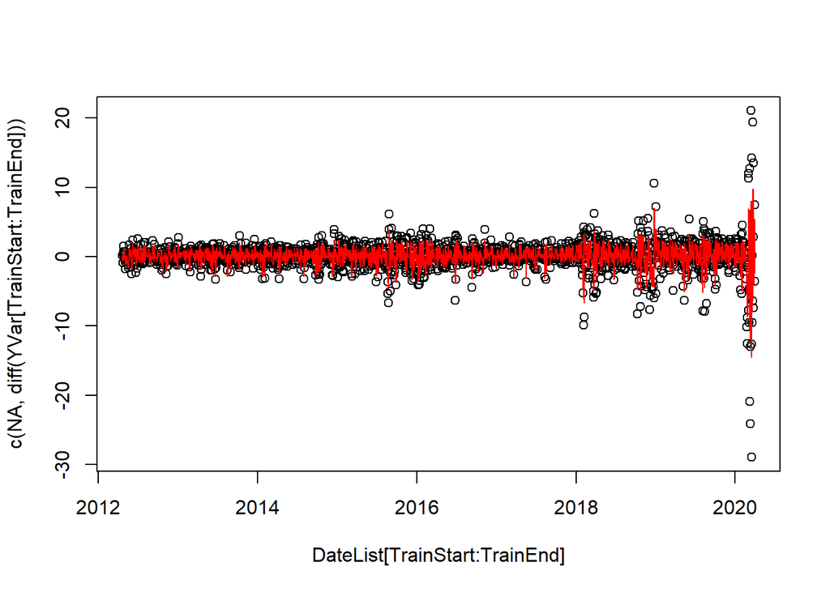

```r
set.seed(10001)

RFModel = randomForest(y = as.vector(TrainY)
                       ,x = TrainX
                       ,ntree = 10000
                       ,mintry = 20
                       ,nodesize = 30
                       )

# check how model performs against original data
CheckRF = predict(RFModel, newdata = TrainX)
CheckRF = CheckRF * CloseMax

plot(x = DateList[TrainStart:TrainEnd], y = c(NA,diff(YVar[TrainStart:TrainEnd])))
lines(x = DateList[TrainStart:TrainEnd], y = CheckRF, col = "red")
```

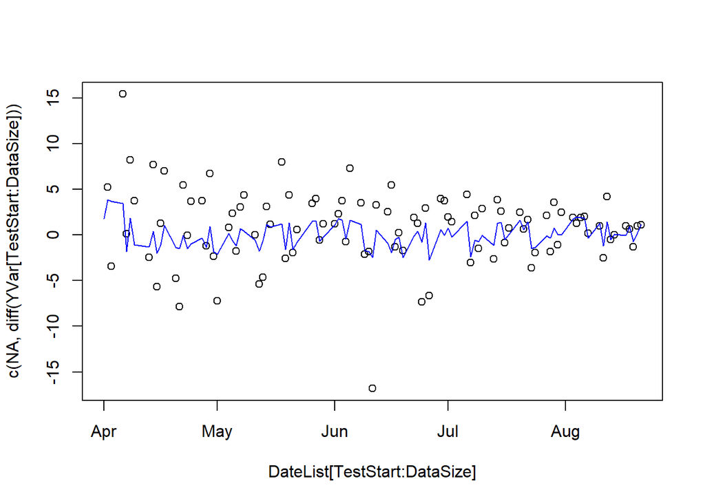

```r
# Predict model
PredictRF = predict(RFModel, newdata = TestX)
PredictRF = PredictRF * CloseMax

plot(x = DateList[TestStart:DataSize], y = c(NA,diff(YVar[TestStart:DataSize])))
lines(x = DateList[TestStart:DataSize], y = PredictRF, col = "blue")
```

Next will be an eXtreme Gradient Boost model. This model will have 10,000 rounds and run on 7 threads. The other factors will be modified to reduce overfitting.

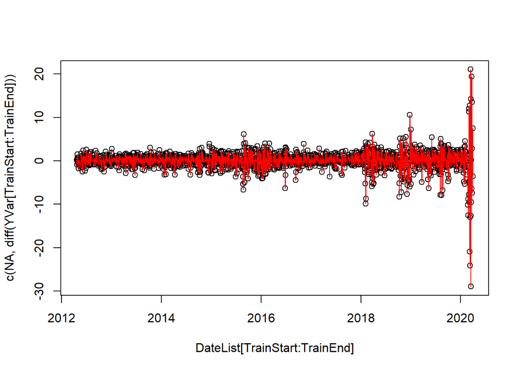

```r
set.seed(10001)

XGBModel = xgboost(data = TrainX
                   ,label = TrainY
                   ,nrounds = 10000
                   ,nthread = 7
                   ,verbose = FALSE
                   ,eta = .1
                   ,gamma = 0
                   ,subsample = .8

                   ,colsample_bylevel = 2/3
                   ,min_child_weight = 0
                   ,max_delta_step = 0
                   ,num_parallel_tree = 10
                   ,early_stopping_rounds = 50
                   ,objective = "reg:squarederror"
                    )

# check how model performs against original data
CheckXGB = predict(XGBModel, newdata = TrainX)
CheckXGB = CheckXGB * CloseMax

plot(x = DateList[TrainStart:TrainEnd], y = c(NA,diff(YVar[TrainStart:TrainEnd])))
lines(x = DateList[TrainStart:TrainEnd], y = CheckXGB, col = "red")
```

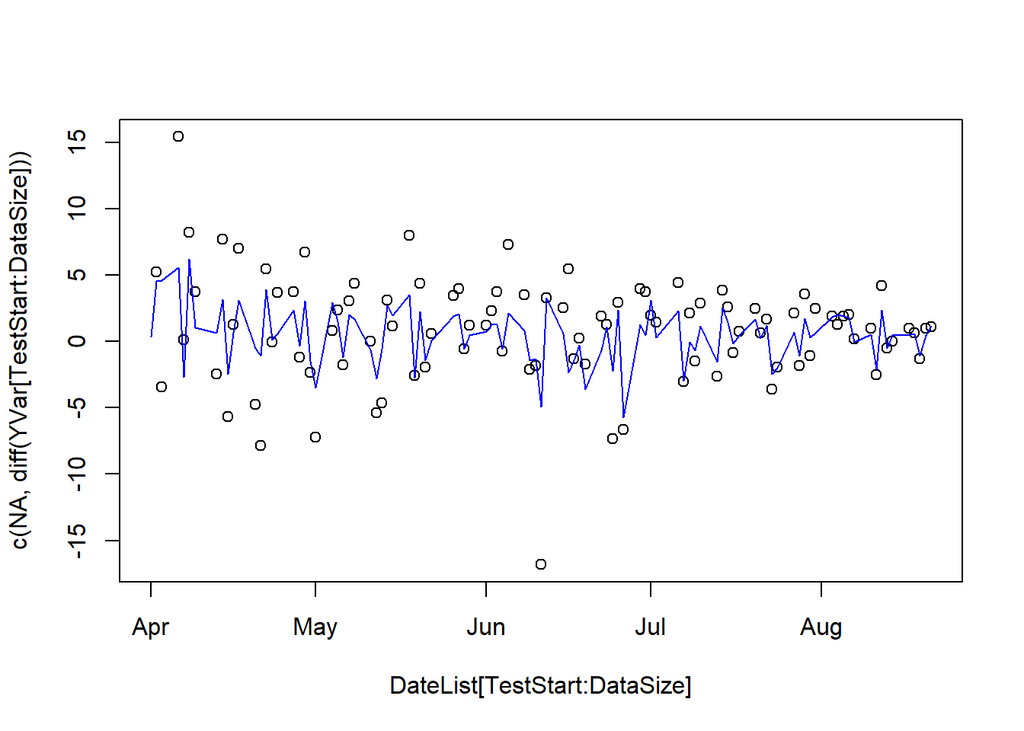

```r
# Predict model
PredictXGB = predict(XGBModel, newdata = TestX)
PredictXGB = PredictXGB * CloseMax

plot(x = DateList[TestStart:DataSize], y = c(NA,diff(YVar[TestStart:DataSize])))
lines(x = DateList[TestStart:DataSize], y = PredictXGB, col = "blue")
```

```r
# RF Model
sum(na.omit(sqrt((c(NA,diff(YVar[TestStart:DataSize])) - PredictRF)^2)))
```

```
## [1] 236.2208
```

```r
# XGB Model
sum(na.omit(sqrt((c(NA,diff(YVar[TestStart:DataSize])) - PredictXGB)^2)))
```

```
## [1] 178.4208
```